# PC GP03 07 C/NC - dead

## Percussion (2019-08-15)

- 3 hits at 35 deg:
1. Hit 1: 10.8 atm, ICP from 7 to 27 at 14:44 pm
2. Hit 2: 12.4 atm, ICP from 26 to 38 at 14:45 pm
3. Hit 3: 9.50 atm, ICP from 21 to 40 at 14:46 pm

Pig dead at 10:15 am (next day - 19h )

## Cooling

Started at 14:54 pm.  
- Brain temperature was 35.5 deg, warmed up to 37 deg.  
Cooled down to 34 deg at 08:45 am (next day).

## Cooling set up

#### Description

For the first 2-h the brain temperature gradually increased from 35.5oC immediately after FPI to 37oC which was set as the maintenance temperature. Starting from 8 h post FPI, the ICP and Heart rate started to increase and has to be controlled by max PPF, FNL and 0.5% ISO. The CTP at 11.5 hour post (2:15 am) showed massive decrease in blood flow to the cortex. After reviewing the results, at 8:45 am decided to cool down the brain to 34oC. As soon as the brain temperature dropped, the ICP and heart rate drops in synchrony. Decided to decrease the Iso to 0% from 0.25% then ICP and heart rate increased, turned back ISO to 0.25% to stabilize the ICP and heart rate.

| Scan time | Description |
| --- | --- |
| 14:32 | Baseline |
| 15:02 | 20 min post |
| 15:17 | 30 min post |
| 15:47 | 60 min post |
| 16:45 | 2h post |
| 18:45 | 4h post |
| 21:45 | 7h post |
| 22:45 | 8h post |
| 02:15 | 11.5h post |
| 06:45 | 16h post |
| 08:45 | Cool to 34 deg |
| 10:10 | 19h post |

## Surgivet and cooling data

Cooled down to 34 deg at 8:45 am (next day).  
Pig dead at 10:15 am (next day - 19h).

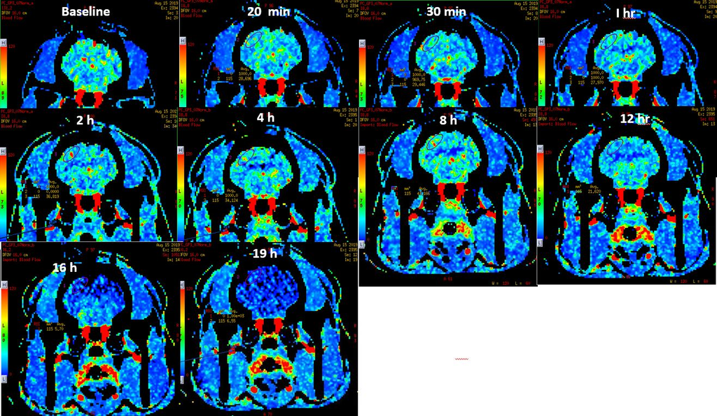

[figure not shown]

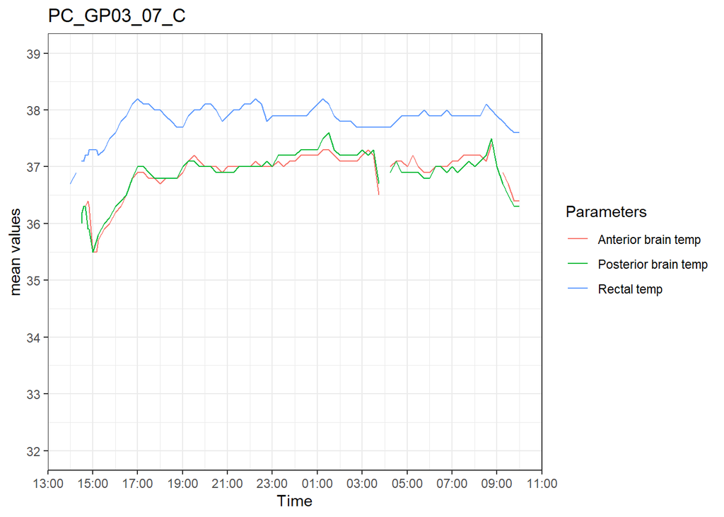

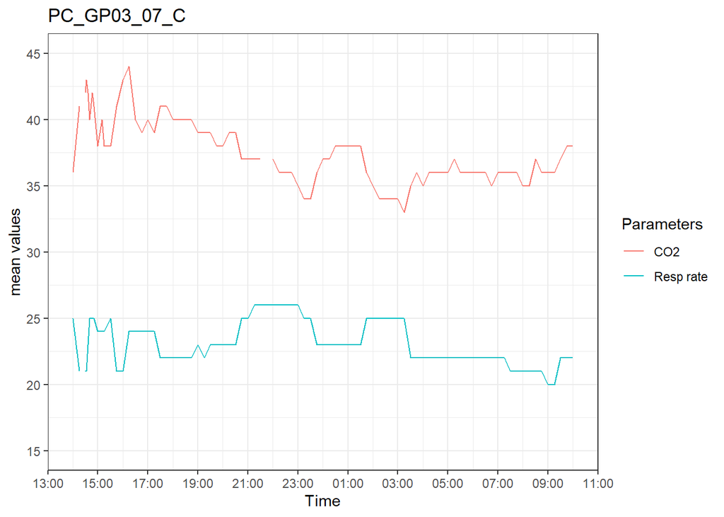

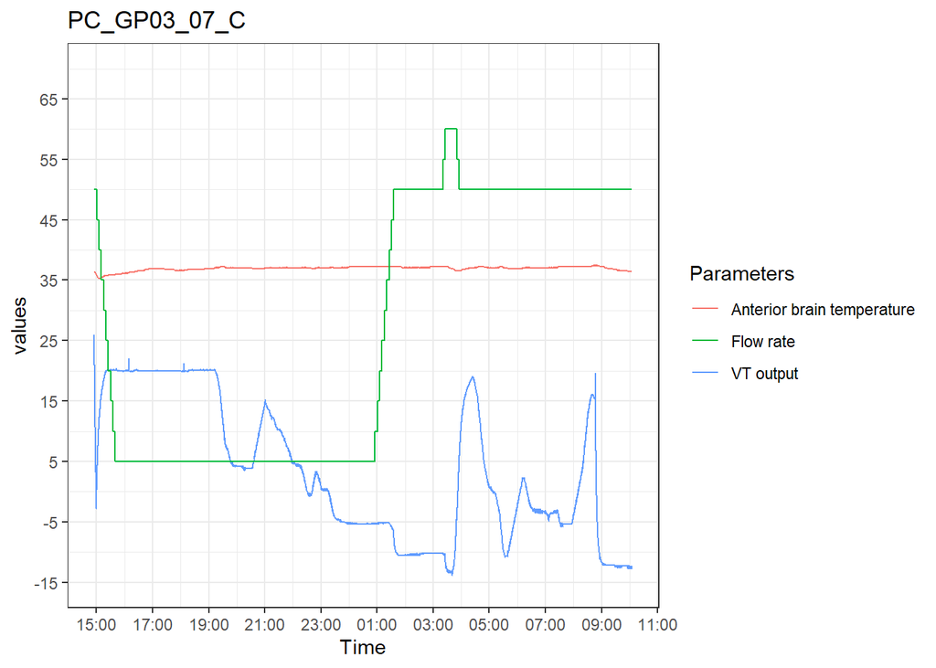